# Homework Tidyverse

Hamid Semiyari

```r
if(!require("pacman")) install.packages("pacman")
pacman::p_load(tidyverse, gapminder, broom)
```

# Problem 1:

Copy paste and run the tribble given below.

```r
tribble( ~x,    ~y,    ~w,    ~z,
              210,   300,   220,   180,
              102,   100,   119,   187,
              176,   175,   188,   173,
              87,    95,   91,     94,
              202,   210,  234,    218,
              110,   122,  131,    128,
) -> dt
```

## 1_a:

- Use and show a `map` function to find the “mean” of each column of the `dt` data table

```r
map(dt,mean)
```

```
$x
[1] 147.8333

$y
[1] 167

$w
[1] 163.8333

$z
[1] 163.3333
```

## 1_b:

- Use and show a `map` function to find the “standard deviation” of each column of the `dt` data table.

```r
map(dt,sd)
```

```
$x
[1] 54.45151

$y
[1] 79.12016

$w
[1] 58.40348

$z
[1] 44.66617
```

## 1_c:

- Use and show a map function that will calculate the “square root” of each value of each column of the data table `dt`.

```r
map(dt,sqrt)
```

```
$x
[1] 14.491377 10.099505 13.266499  9.327379 14.212670 10.488088

$y
[1] 17.320508 10.000000 13.228757  9.746794 14.491377 11.045361

$w
[1] 14.832397 10.908712 13.711309  9.539392 15.297059 11.445523

$z
[1] 13.41641 13.67479 13.15295  9.69536 14.76482 11.31371
```

## 1_d:

- Use R code to find the “mean”, “max”, “1st Quartile”, “3rd Quartile”, “Median”, and “Min” for each column of the `dt` data table. (Hint: You do not have to use a map function)

```r
summary(dt)
```

```
       x               y               w               z
 Min.   : 87.0   Min.   : 95.0   Min.   : 91.0   Min.   : 94.0
 1st Qu.:104.0   1st Qu.:105.5   1st Qu.:122.0   1st Qu.:139.2
 Median :143.0   Median :148.5   Median :159.5   Median :176.5
 Mean   :147.8   Mean   :167.0   Mean   :163.8   Mean   :163.3
 3rd Qu.:195.5   3rd Qu.:201.2   3rd Qu.:212.0   3rd Qu.:185.2
 Max.   :210.0   Max.   :300.0   Max.   :234.0   Max.   :218.0
```

# Problem 2:

Write a function that uses a for loop that, for each iteration, randomly draws 5 observations from an exponential distribution with “rate” parameter 1 (use `rexp()`) and calculates its “mean”. It should do this 10,000 times. Choose an appropriate plot to plot the distribution of “means”.

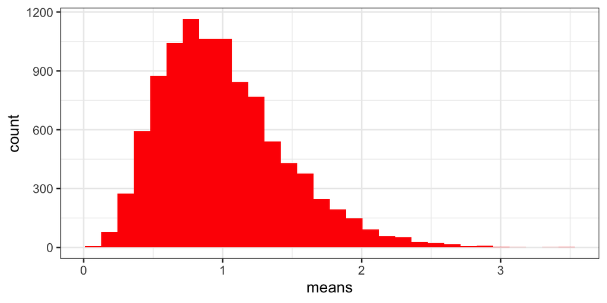

```r
vector("integer",10000) ->vector_1
random_vector <-function(vector_1)
{for (i in 1:length(vector_1))
  vector_1[i]=mean(rexp(5, rate = 1))
vector_1 <- data.frame(means = vector_1)
return(vector_1)}
random_vector(vector_1)-> vector_2
ggplot(vector_2, aes(x=means))+
  geom_histogram(fill="red")
```

## 2_a:

- Repeat part 1 by using a `map_*()` function.

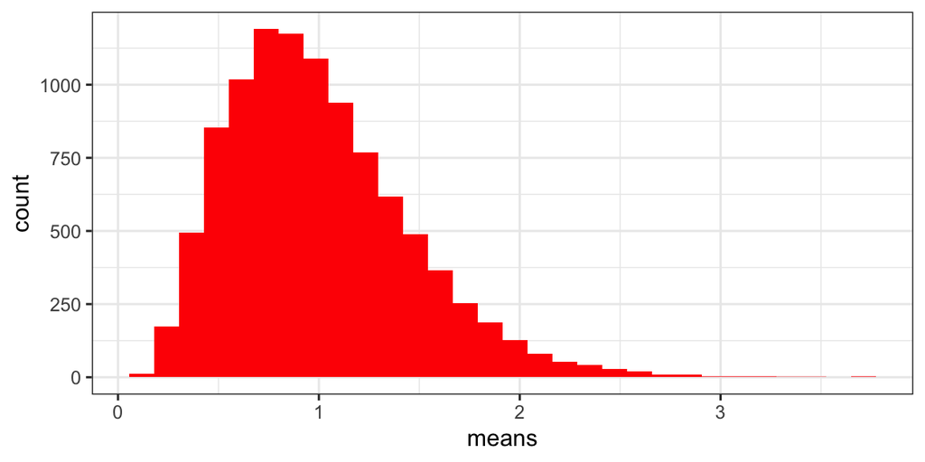

```r
vector("integer",10000) ->vector_3
random_numbers <-function(x)
  mean(rexp(5, rate = 1))
map_dbl(vector_3, random_numbers) ->vector_4
vector_4 <- data.frame(means = vector_4)
ggplot(vector_4, aes(x=means))+
  geom_histogram(fill="red")
```

## 2_b:

- Repeat part 1 by using the `replicate()` function.

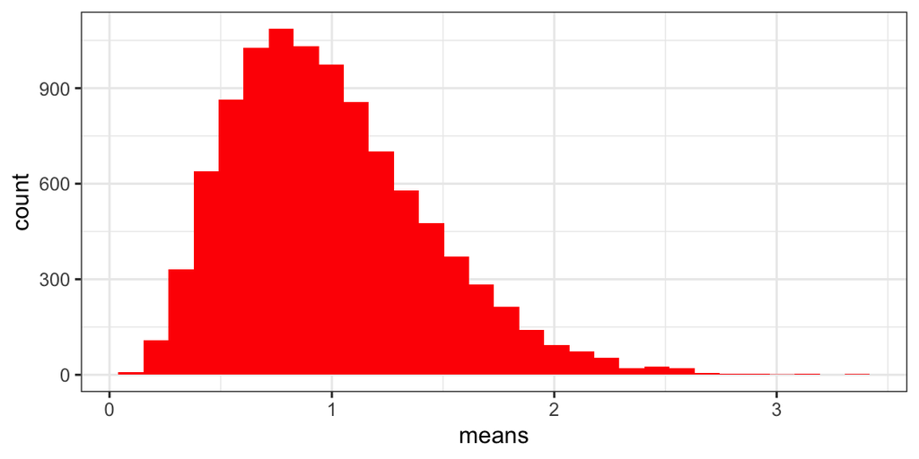

```r
replicate(10000,mean(rexp(5, rate = 1))) -> vector_5
vector_6 <- data.frame(means = vector_5)
ggplot(vector_6, aes(x=means))+
  geom_histogram(fill="red")
```

## 2_c:

- Use a another for loop that will print out plots for sample sizes of 5, 10, and 20 observations (instead of just 5).

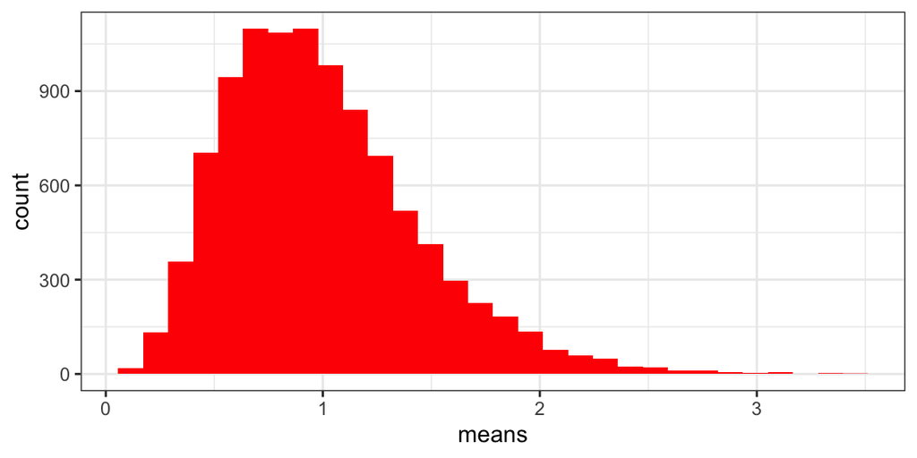

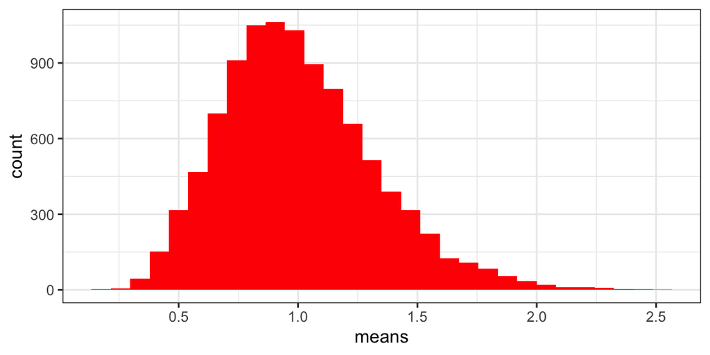

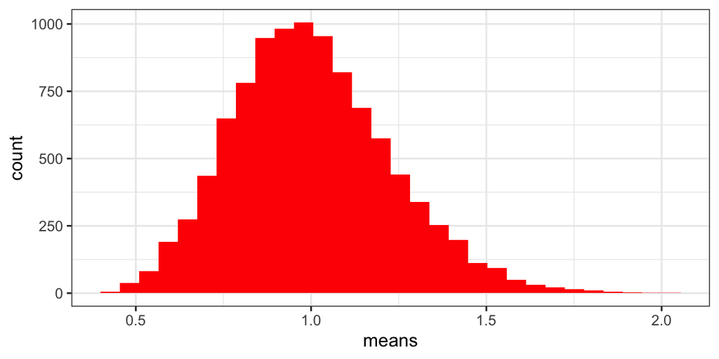

```r
random_vector <-function(x)
{vector_1 <- vector("integer",10000)
for (i in 1:length(vector_1))
  vector_1[i]=mean(rexp(x, rate = 1))
vector_1 <- data.frame(means = vector_1)
ggplot(vector_1, aes(x=means))+
  geom_histogram(fill="red")}
for (i in 1:4)
  if (i!=3)
    print(random_vector(i*5))
```

# Problem 3:

- Use and show R coding to calculate the “standard deviation” for each variable of the data table `mtcars` using the “Special For Loop Method”.

**Note:**

- There are two methods. Please see a quick explanation for both methods in below:
  - Method 1:

```r
  multi_return <- function() {
    my_list <- list("color" = "red", "size" = 20, "shape" = "round")
    return(my_list)
  }
```

```r
a <- multi_return()
a$color
```

```
[1] "red"
```

```r
a<- multi_return()
a$shape
```

```
[1] "round"
```

```r
a<- multi_return()
a$size
```

```
[1] 20
```

- Method 2. The “Special For Loop Method”

```r
output <- vector("double", ncol(df))  # 1. output (use appropriate data frame instead of df)
for (i in seq_along(df)) {            # 2. sequence
  output[[i]] <- median(df[[i]])      # 3. body
}
output
```

- **Solution:** coding to calculate the “standard deviation” for each variable

```r
output <- vector("double", ncol(mtcars))
for (i in seq_along(mtcars)) {
  output[[i]] <- sd(mtcars[[i]])
}
output
```

[output not shown]

# Problem 4:

Generate a sequence of dates from **January 1, 2015** to **December 31, 2025**, spaced by every **two months**. Extract the **year**, **quarter**, and **ISO week number** for each date.

```r
seq(as.Date("2015-01-01"), as.Date("2025-12-31"), by = "2 months") ->dates

extracted_dates <- data.frame(
  "year"=year(dates),
  "quarter"=quarter(dates),
  "ISO_week"=isoweek(dates)

)
extracted_dates
```

```
   year quarter ISO_week
1  2015       1        1
2  2015       1        9
3  2015       2       18
4  2015       3       27
5  2015       3       36
6  2015       4       44
7  2016       1       53
8  2016       1        9
9  2016       2       17
10 2016       3       26
11 2016       3       35
12 2016       4       44
13 2017       1       52
14 2017       1        9
```

[output cut: 52 more lines]

# Problem 5

Given the following dates, compute the difference in **months** and **weeks** between each consecutive pair.

```r
sample_dates <- c("2018-03-15", "2020-07-20", "2023-01-10", "2025-09-05")
```

```r
months_weeks <- data.frame(
  "full_date"= sample_dates,
  "month"=month(sample_dates),
  "week"=week(sample_dates),
  "year"=year(sample_dates)
)
months_weeks
```

```
   full_date month week year
1 2018-03-15     3   11 2018
2 2020-07-20     7   29 2020
3 2023-01-10     1    2 2023
4 2025-09-05     9   36 2025
```

```r
i=1
j=2
nrow(months_weeks)
```

```
[1] 4
```

```r
while (j<=nrow(months_weeks))
  {total_months=0
  months_difference=(months_weeks$year[j]-months_weeks$year[i])
  total_months=months_difference*12
  inyear_difference=months_weeks$month[j]-months_weeks$month[i]
  total_months=total_months+inyear_difference
  total_days=as.Date(months_weeks$full_date[j])-as.Date(months_weeks$full_date[i])
  total_days=as.numeric(total_days)
  total_weeks=total_days/7
  total_weeks=round(total_weeks,3)
  print(paste("Total Month Difference:",total_months, "Total Week Difference:",total_weeks))
  i=i+1
  j=j+1}
```

```
[1] "Total Month Difference: 28 Total Week Difference: 122.571"
[1] "Total Month Difference: 30 Total Week Difference: 129.143"
[1] "Total Month Difference: 32 Total Week Difference: 138.429"
```

# Problem 6

Given a list of mixed date formats, use `map()` and `possibly()` from `purrr` to safely convert them to **Date** format and extract the **month name**.

```r
date_strings <- list("2023-06-10", "2022/12/25", "15-Aug-2021", "InvalidDate")
```

```r
date_strings2 <-list("2023-06-10", "2022/12/25", parse_date_time("15-Aug-2021", orders = c("ymd", "dmy")), "InvalidDate")
valid_date <- possibly(as.Date, otherwise = as.Date("2022-01-01"))
map(date_strings2,valid_date)->safe_dates
safe_dates
```

```
[[1]]
[1] "2023-06-10"

[[2]]
[1] "2022-12-25"

[[3]]
[1] "2021-08-15"

[[4]]
[1] "2022-01-01"
```

```r
safe_dates <- list_c(safe_dates)
safe_dates_parsed <- data.frame(
  "Date"=safe_dates,
  "Month_Name"=month(safe_dates, label = TRUE, abbr = FALSE)

)
safe_dates_parsed
```

```
        Date Month_Name
1 2023-06-10       June
2 2022-12-25   December
3 2021-08-15     August
4 2022-01-01    January
```